# Drug Abuse Report

[figure not shown]

**The goal of this project is to analyze the 2013 edition of the National Survey on Drug Use and Health (NSDUH) conducted by the Substance Abuse & Mental Health Data Archive (SAMHDA). This is an annual survey about the drug use and health of the civilian, noninstitutionalized population of the United States over 12 years of age.**

**The NSDUH is the primary source on statistics about the drug use of the United States population and has been conducted by the federal government since 1971. The survey is conducted through face-to-face, computer-assisted interviews with a representative sample in the respondents’ place of residence.**

**Due to the sensitive nature of this survey, no attempts were made or shall be made to connect responses to respondents. If any connections are made, report them to CBHSQ and SAMHDA (samhda-support@icpsr.umich.edu)**

**The purpose of this survey is to measure the prevalence and correlates of drug use and abuse in the United States. Subjects are from the United States and are aged 12 and over. The survey oversamples the younger populations, and numbers of respondents are equally distributed among the age groups of 12-17, 18-25, and 26+**

**It should be noted that recreational drug use (that this survey focuses on) and abuse is frowned upon in society. For this reason, respondents may not be entirely truthful in their responses, even though they were given full anonymity. Additionally, questions about respondents’ history are subject to problems in remembering exact events in the past.**

**Findings included in this report were only the ones that were not covered by the official NSDUH 2013 results which are available at [the SAMHSA website](http://www.samhsa.gov/data/sites/default/files/NSDUHresultsPDFWHTML2013/Web/NSDUHresults2013.pdf).**

**There were a total of 55,160 (with a response rate of 84%) responces, each of whom were paid $30 for their time.**

### RStudio Session Information

```r
library("DBI", lib.loc="~/R/win-library/3.0")
library("devtools", lib.loc="~/R/win-library/3.0")
library("ggplot2", lib.loc="~/R/win-library/3.0")
library("gtools", lib.loc="~/R/win-library/3.0")
library("knitr", lib.loc="~/R/win-library/3.0")
library("markdown", lib.loc="~/R/win-library/3.0")
library("plyr", lib.loc="~/R/win-library/3.0")
library("RCurl", lib.loc="~/R/win-library/3.0")
library("rJava", lib.loc="~/R/win-library/3.0")
library("RJDBC", lib.loc="~/R/win-library/3.0")
library("rmarkdown", lib.loc="~/R/win-library/3.0")
library("sqldf", lib.loc="~/R/win-library/3.0")
library("stats", lib.loc="C:/Program Files/R/R-3.0.3/library")
```

```r
opts_chunk$set(tidy.opts=list(width.cutoff=400))
```

### Data Manipulation

```
#Core Substance Abuse CIGEVER-SVDAYPWK  2   354
#Imputed Substance Use IRCIGRC-FUIEM21  355     850
#Selected Unedited Variables CG05-SV13  851     964
#Non-core HERSMOKE-GQTYPE2  965     3056
#Demographics AGE2-II2EMST4     3057    3134
#Geographic PDEN00-MAIIN002     3135    3137

core_substance=""
imputed_substance=""
selected_unedited=""
non_core=""
demographics=""
geographic=""

infile=open("2013Data.tsv", "r")
core_out=open("core_substance.csv", "wb")
imputed_out=open("imputed_substance.csv", "wb")
selected_out=open("selected_unedited.csv", "wb")
non_out=open("non_core.csv", "wb")
demographics_out=open("demographics.csv", "wb")
geographic_out=open("geographic.csv", "wb")

for line in infile:
    split_line=line.split()

    #print "CORE SUBSTANCE"
    for i in range(2,354+1):
        if i==2:
            core_out.write(split_line[i])
        else:
            core_out.write(", " + split_line[i])
    core_out.write("\n")

    # print "IMPUTED SUBSTANCE"
    for i in range(355,850+1):
        if i==355:
            imputed_out.write(split_line[i])
        else:
            imputed_out.write(", " + split_line[i])
    imputed_out.write("\n")
```

[output cut: 17 more lines]

```
    # print "DEMOGRAPHICS"
    for i in range(3057,3134+1):
        if i==3057:
            demographics_out.write(split_line[i])
        else:
            demographics_out.write(", " + split_line[i])
    demographics_out.write("\n")

    # print "GEOGRAPHIC"
    for i in range(3135,3137+1):
        if i==3135:
            geographic_out.write(split_line[i])
        else:
            geographic_out.write(", " + split_line[i])
    geographic_out.write("\n")
```

The data from the SAMHDA were originally in one very large table, so I used a python script to split them into multiple tables based upon levels of organization given by the SAMHDA. This code takes in the original data file and converts it into csv files for each different subtable that I create.

```
core_in=open("core_substance.csv", "r")
imputed_in=open("imputed_substance.csv", "r")
selected_in=open("selected_unedited.csv", "r")
non_in=open("non_core.csv", "r")
demographics_in=open("demographics.csv", "r")
geographic_in=open("geographic.csv", "r")

core_out=open("core_substance2.csv", "wb")
imputed_out=open("imputed_substance2.csv", "wb")
selected_out=open("selected_unedited2.csv", "wb")
non_out=open("non_core2.csv", "wb")
demographics_out=open("demographics2.csv", "wb")
geographic_out=open("geographic2.csv", "wb")

count=0
first=core_in.readline()
first="ID, " + first
core_out.write(first)
for line in core_in:
  core_out.write(str(count) + ", " + line)
    count+=1

count=0
first=imputed_in.readline()
first="ID, " + first
imputed_out.write(first)
for line in imputed_in:
    imputed_out.write(str(count) + ", " + line)
    count+=1

count=0
first=selected_in.readline()
first="ID, " + first
selected_out.write(first)
for line in selected_in:
    selected_out.write(str(count) + ", " + line)
    count+=1

count=0
first=non_in.readline()
first="ID, " + first
non_out.write(first)
for line in non_in:
    non_out.write(str(count) + ", " + line)
    count+=1

count=0
first=demographics_in.readline()
first="ID, " + first
demographics_out.write(first)
for line in demographics_in:
    demographics_out.write(str(count) + ", " + line)
    count+=1

count=0
first=geographic_in.readline()
first="ID, " + first
geographic_out.write(first)
for line in geographic_in:
    geographic_out.write(str(count) + ", " + line)
    count+=1
```

Later I realized that the IDs for the cases had not gotten through, so this python script re-adds them.

```
core=open("core_substance.csv", "r")
imputed=open("imputed_substance.csv", "r")
selected=open("selected_unedited.csv", "r")
non=open("non_core.csv", "r")
demographics=open("demographics.csv", "r")
geographic=open("geographic.csv", "r")
ddl_for_tables=open("table_ddl.txt", "wb")

ddl_for_tables.write("\n\nCORE SUBSTANCE XXXXXXXXXXXXXXXXXXXXXXXXXXXXXXXXXXXXXXXXXXXXXXXXXXXXXXXXXXXXXXXX\n\n")
variables=core.readline().replace(' ','').split(',')
for variable in variables:
  ddl_for_tables.write(variable + " NUMBER, \n")

ddl_for_tables.write("\n\nIMPUTED SUBSTANCE XXXXXXXXXXXXXXXXXXXXXXXXXXXXXXXXXXXXXXXXXXXXXXXXXXXXXXXXXXXXXXXX\n\n")
variables=imputed.readline().replace(' ','').split(',')
for variable in variables:
    ddl_for_tables.write(variable + " NUMBER, \n")

ddl_for_tables.write("\n\nSELECTED UNEDITED XXXXXXXXXXXXXXXXXXXXXXXXXXXXXXXXXXXXXXXXXXXXXXXXXXXXXXXXXXXXXXXX\n\n")
variables=selected.readline().replace(' ','').split(',')
for variable in variables:
    ddl_for_tables.write(variable + " NUMBER, \n")

ddl_for_tables.write("\n\nNON CORE XXXXXXXXXXXXXXXXXXXXXXXXXXXXXXXXXXXXXXXXXXXXXXXXXXXXXXXXXXXXXXXX\n\n")
variables=non.readline().replace(' ','').split(',')
for variable in variables:
    ddl_for_tables.write(variable + " NUMBER, \n")

ddl_for_tables.write("\n\nDEMOGRAPHICS XXXXXXXXXXXXXXXXXXXXXXXXXXXXXXXXXXXXXXXXXXXXXXXXXXXXXXXXXXXXXXXX\n\n")
variables=demographics.readline().replace(' ','').split(',')
for variable in variables:
    ddl_for_tables.write(variable + " NUMBER, \n")

ddl_for_tables.write("\n\nGEOGRAPHIC XXXXXXXXXXXXXXXXXXXXXXXXXXXXXXXXXXXXXXXXXXXXXXXXXXXXXXXXXXXXXXXX\n\n")
variables=geographic.readline().replace(' ','').split(',')
for variable in variables:
    ddl_for_tables.write(variable + " NUMBER, \n")
```

Here, I generate the SQL ddl for each of the constituent tables.

```
def diff(a, b):
    b = set(b)
    return [aa for aa in a if aa not in b]

non_in=open("non_core2.csv", "r")
non_in2=open("non_core2.csv", "r")
non_cols_to_keep=open("noncore_cols_to_keep.txt", "r")
non_out=open("non_core3.csv", "wb")

vars_to_keep=[]
indexes_to_keep=[]

for line in non_cols_to_keep:
  vars_to_keep.append(line.rstrip('\n'))

first=non_in.readline().split()
first2=[]

for x in first:
    first2.append(x.replace(',', ''))

indexes_to_keep.append(0)
for x in vars_to_keep:
    indexes_to_keep.append(first2.index(x))

all_indexes=range(len(first2))
print len(all_indexes)

indexes_to_delete = diff(all_indexes,indexes_to_keep)

for line in non_in2:
    temp=line.split()
    for x in indexes_to_delete:
        temp[x]=''
    #non_out.write(''.join(temp))
    non_out.write("".join(str(e) for e in temp)[:-1])
    non_out.write("\n")
```

This removes unneeded variables from the Non-Core data for space efficiency and ease of use with the data mining algorithms.

```
non_in=open("non_core3.csv", "r")
non_out=open("non_core3.ddl", "wb")

first=non_in.readline()
vars=first.split(',')
vars[-1]=vars[-1].rstrip('\n')

for x in vars:
  non_out.write(x + "XXXX NUMBER, \n")
```

Finally, this creates Non-Core DDL from the trimmed Non-Core data.

### Tobacco

Tobacco use was one of the factors considered to be most important to analyze in this project due to the harm its use can cause and its prevalence in our society. The focus was largely on determining the factors that coincide with cigarette use.

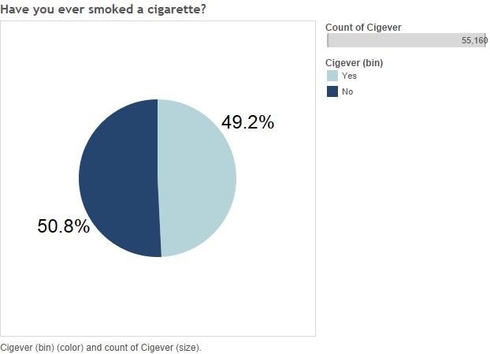

To give an overview of tobacco usage among the respondents, here are the percentages of respondents who have and have not smoked a cigarette in their lives.

#### Frequency

In addition to the percentage of respondents who have smoked, it is also good to know how much each individual is likely to smoke.

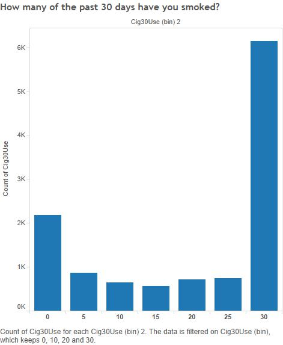

The greatest value by far is 30 days, indicating smoking on all of the last 30 days. This graph is shocking, but recall that this only includes respondents who have used cigarettes and who have used cigarettes in the past 30 days. Among all respondents, 11.1% smoked all of the past 30 days, but among all respondents who have smoked at all in the past 30 days, 51.5% smoked all 30 days.

#### Peers

One important aspect of life that is affected by tobacco use in many ways is a person’s connections with their friends and family, so it is important to study what those ways might be.

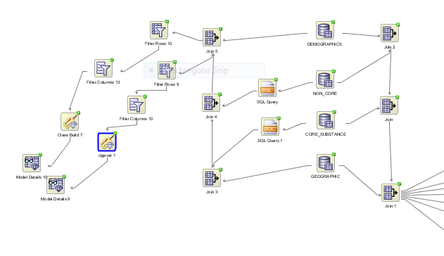

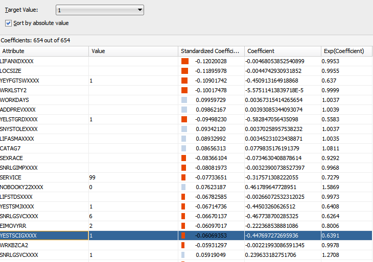

When running a classification analysis on the data to predict factors affecting cigarette usage, YESTSCIG was one of the top confidence attributes and deals with the amount of respondents’ peers who smoke cigarettes.

```
## stat_bin: binwidth defaulted to range/30. Use 'binwidth = x' to adjust this.
```

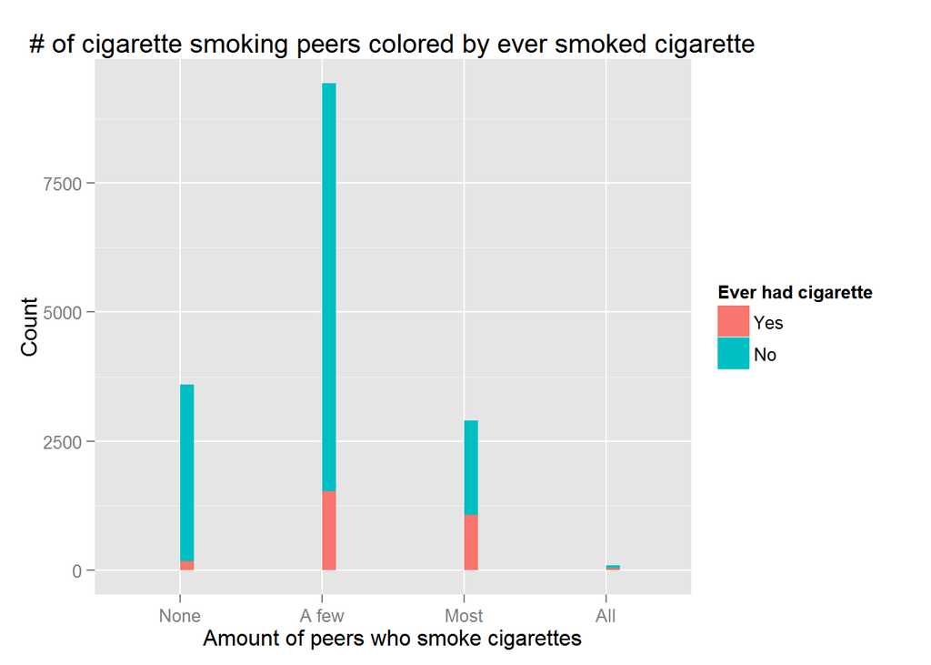

We can roughly see that as more of the respondent’s peers smoke, the more likely the respondent is to smoke as well, but the lengths of the bars makes it difficult to be sure.

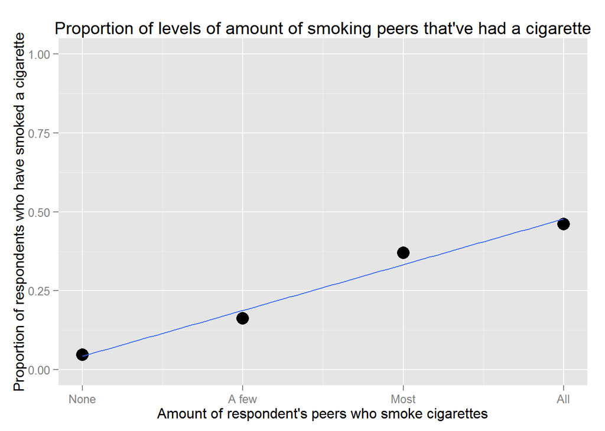

Whenever proportions are graphed in this report, the y-axis will include the full scale of possible values from 0 to 1 so that the results do not appear exaggerated. Also consider the large sample size of 55,000+ which means that even small differences in proportions are quite significant. Now we can see that there is a clear correlation with the amount of the respondent’s peers who smoke cigarettes and the likelihood that the respondent themself has smoked a cigarette as there is a .413 difference in proportions from no peers smoking cigarettes and all peers smoking cigarettes. This is an important point because it provides good support for the idea that “peer pressure” leads many teens to experiment with cigarettes.

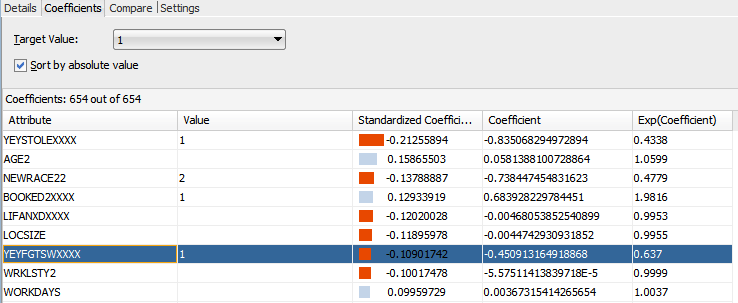

In the same algorithm’s output was a higher confidence attribute, YEYFGTSW (amount of fights the repsondent has gotten into at school or work), for predicting cigarette use.

```
## stat_bin: binwidth defaulted to range/30. Use 'binwidth = x' to adjust this.
```

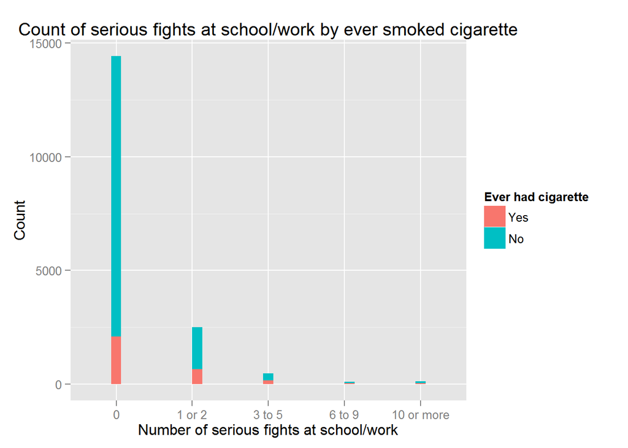

Again, it is difficult to read the graph so we will look at the proportions again. The bars are only included to get a sense of the number of responses for each choice.

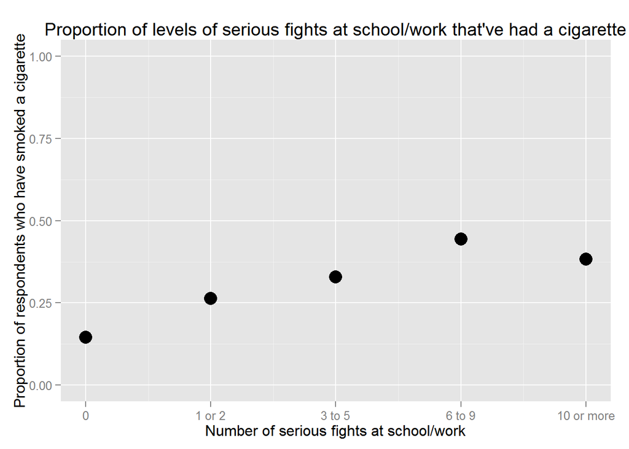

Again we see a linear relationship that suggests that violence is associated with cigarette usage with a difference in proportions from 0 fights to 6-9 fights of .29. This could be explained by several different factors including irritability resulting from periods of nicotine withdrawal, or perhaps an external factor is responsible for both smoking and violence. Notice that the bin for 10 fights and over is an open interval on the right so any number of fights above 10 is included here, which may be the cause of the lower proportion of respondents who have smoked for that bin.

#### Tobacco vs Alcohol

Numerous data mining algorithms suggested a connection between the earlier age a respondent has their first drink and whether or not they have tried a cigarette before, we investigate this by looking at age of first use of alcohol colored by cigarette usage.

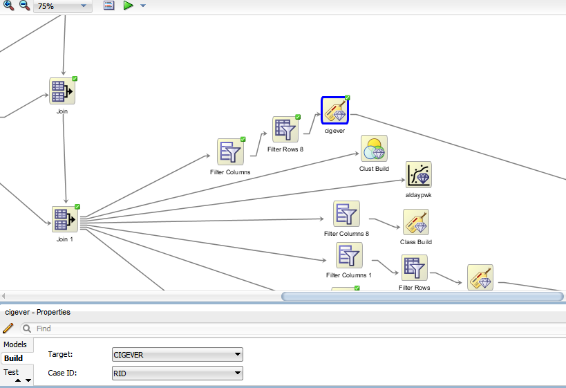

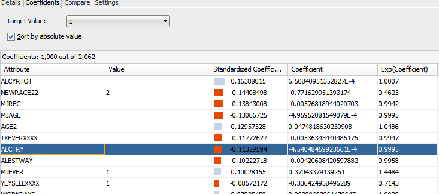

When predicting if a respondent has ever had a cigarette using classification algorithms, ALCTRY, age at which the respondent first had alcohol, had high confidence correlation with the respondent ever having a cigarette. Namely, the younger a person had alcohol for the first time, the more likely it is that they have had a cigarette. In fact, another alcohol variable, ALCYRTOT, the amount of alcohol the person has had in the past year, increases along with cigarette usage and is the top confidence variable.

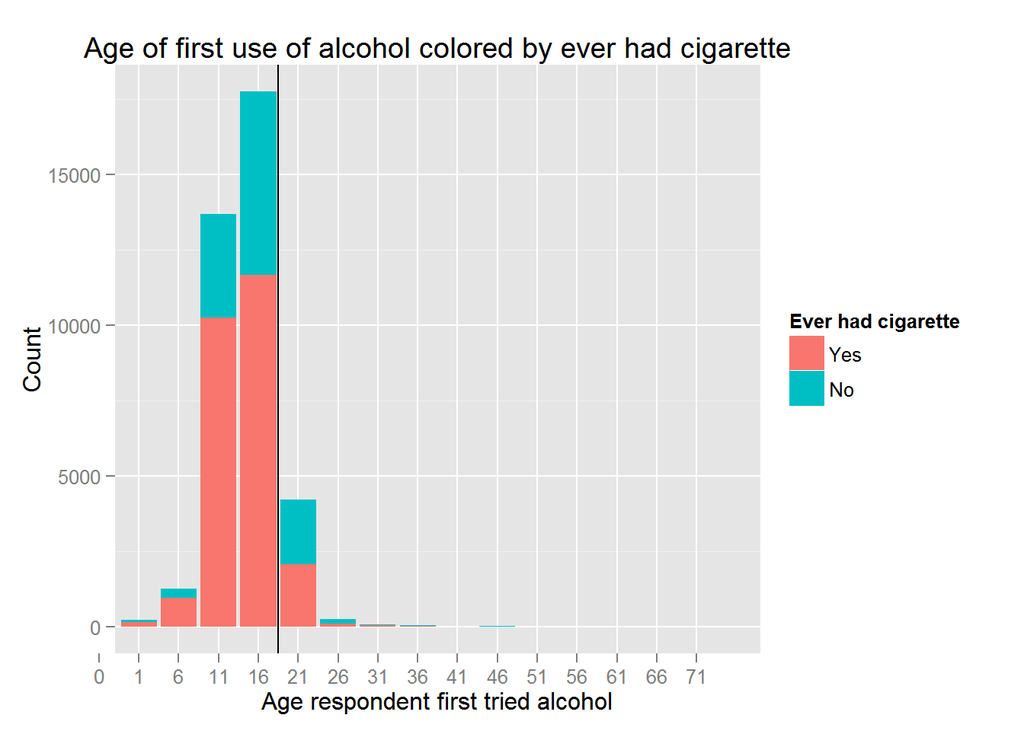

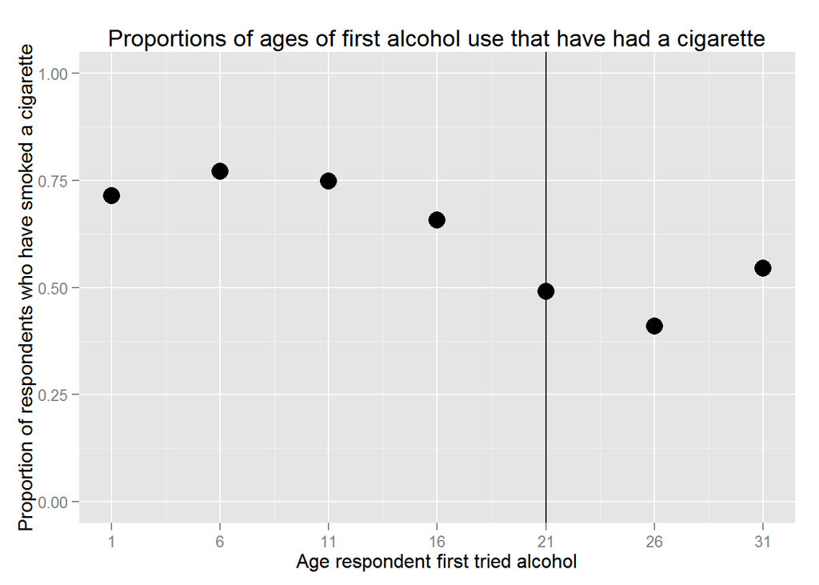

For 6 to 30 year olds the intuition of earlier alcohol use occuring with higher cigarette usage seems to hold up and includes a difference in proportions between the 6 and 26-30 year olds of .36, but those who were 1 to 5 or 31 to 36 years old for their first drink seem to have an unusually low and high (respectively) proportion of respondents who have smoked before compared to the other levels of age. Note that ages above 31 to 36 are not shown because there are not enough samples.

The data mining process also suggested that early alcohol and cigarette usage predict marijuana usage.

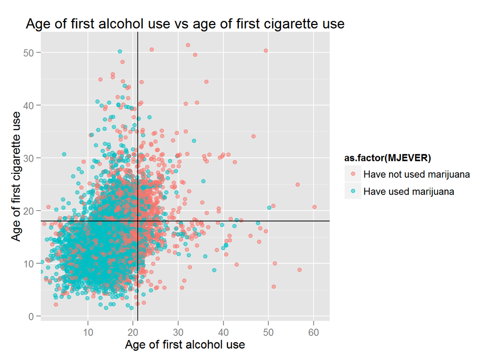

Note that blue points indicate the respondent has used marijuana before, and overplotting due to the 55,000+ samples was treated by making points slightly transparent (so large amounts of points together become more opaque) and by “jittering” (or offsetting points from one another so they do not cover one another) the points. Additionally, the legal drinking age is represented by a vertical line and the legal smoking age is represented by a horizontal line. These lines show that premature alcohol use is more associated with marijuana use than premature cigarette use because the blue points cross the cigarette line more often than the alcohol line. When looking at age of first use of alcohol vs cigarettes colored by marijuana use, there is some support for the idea that early cigarette and alcohol use is correlated with marijuana use.

### Marijuana

As it is the most popular illicit recreational drug and is becoming legalized in many places, it is also important to study marijuana use among respondents.

#### Health

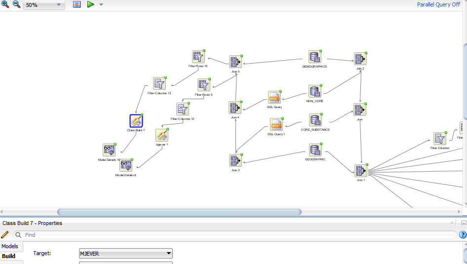

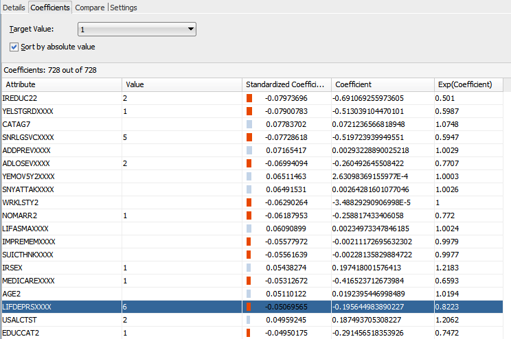

The classification algorithms for prediciting marijuana use included a high confidence attribute LIFDEPRS, if the respondent has ever had depression.

```
## stat_bin: binwidth defaulted to range/30. Use 'binwidth = x' to adjust this.
```

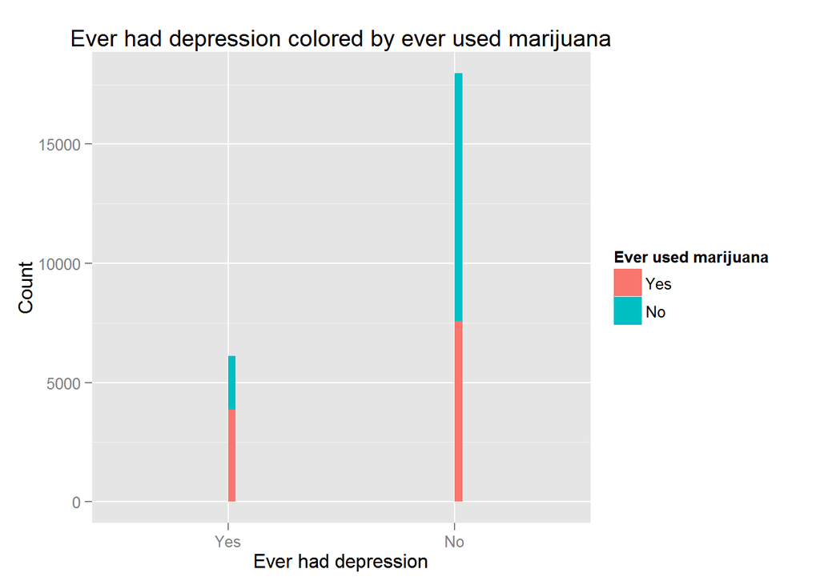

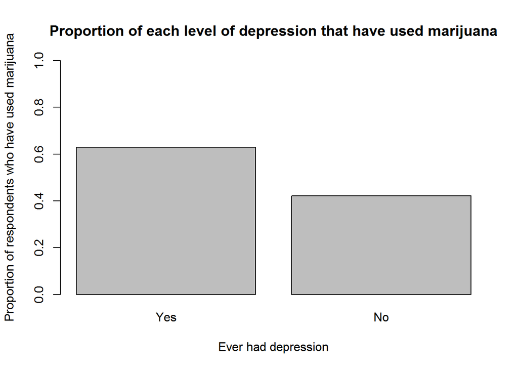

Since there are only two values it is hard to get a sense of whether this result is significant, but after a two proportion z-test (with n1=6117, n2=17970, y1=3852, y2=7563, p^1=.6297, p^2=.4209) with a difference in proportions of .21, a p-value of <.00001 was returned which tells us that there is strong evidence that depression and marijuana use occur together. Whether a person is depressed and seeks out marijuana to treat the depression or whether a marijuana user becomes depressed after using the drug is difficult to tell from our data, however. But there is research that suggests that marijuana is helpful in treating depression and many patients use it for such purposes.

#### Peers

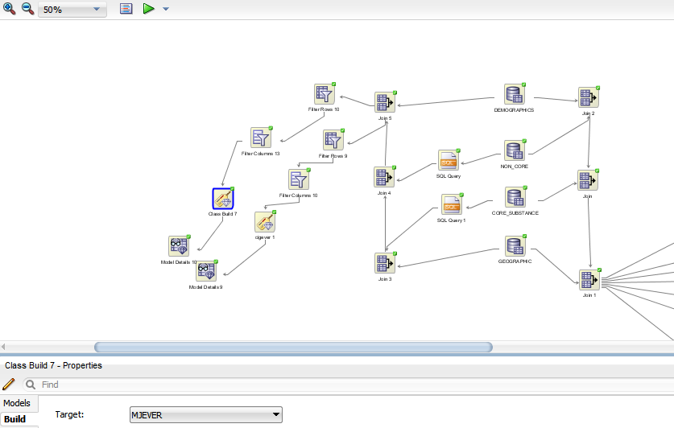

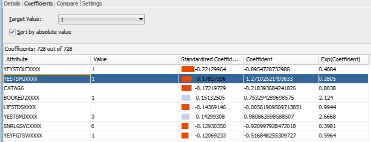

The influence of a respondent’s peers was also evident in the classification algorithm output for predicting marijuana use as well. In fact, peers’ marijuana usage, YESTSMJ, was the second highest confidence predictor for a respondent’s marijuana use.

```
## stat_bin: binwidth defaulted to range/30. Use 'binwidth = x' to adjust this.
```

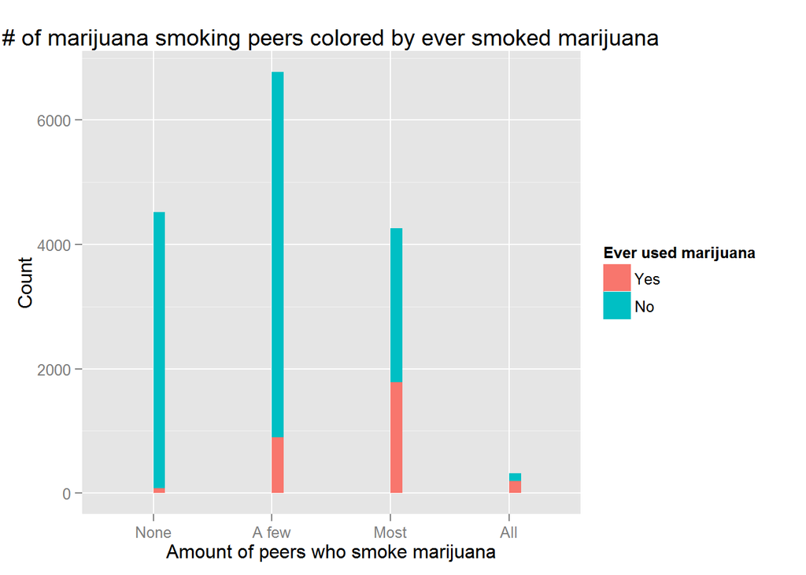

We can clearly see that as more of the respondent’s peers use marijuana, the more likely the respondent is to use marijuana as well.

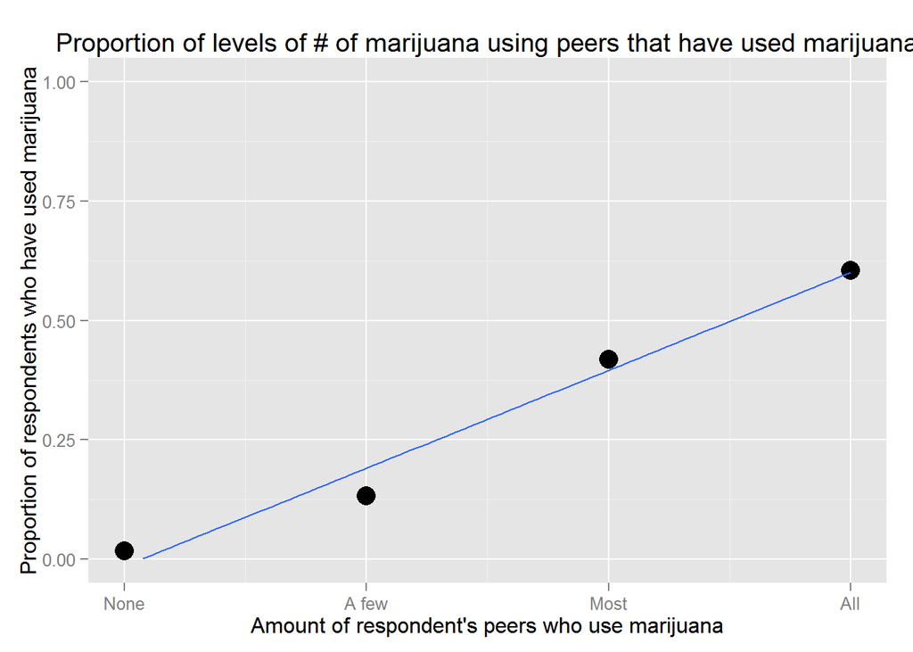

The proportion graph reinforces the idea that people use marijuana more often the more their peers do. This is even clearer here in the case of marijuana than it is in the case of cigarettes as the proportions increase linearly all the way up to .6 as opposed to .46 with cigarettes.

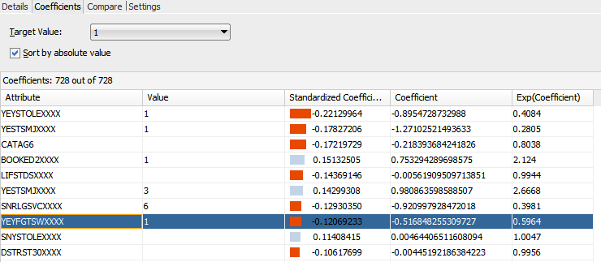

YEYFGTSW, amount of fights the repsondent has gotten into at school or work was also a high confidence predictor for marijuana use.

```
## stat_bin: binwidth defaulted to range/30. Use 'binwidth = x' to adjust this.
```

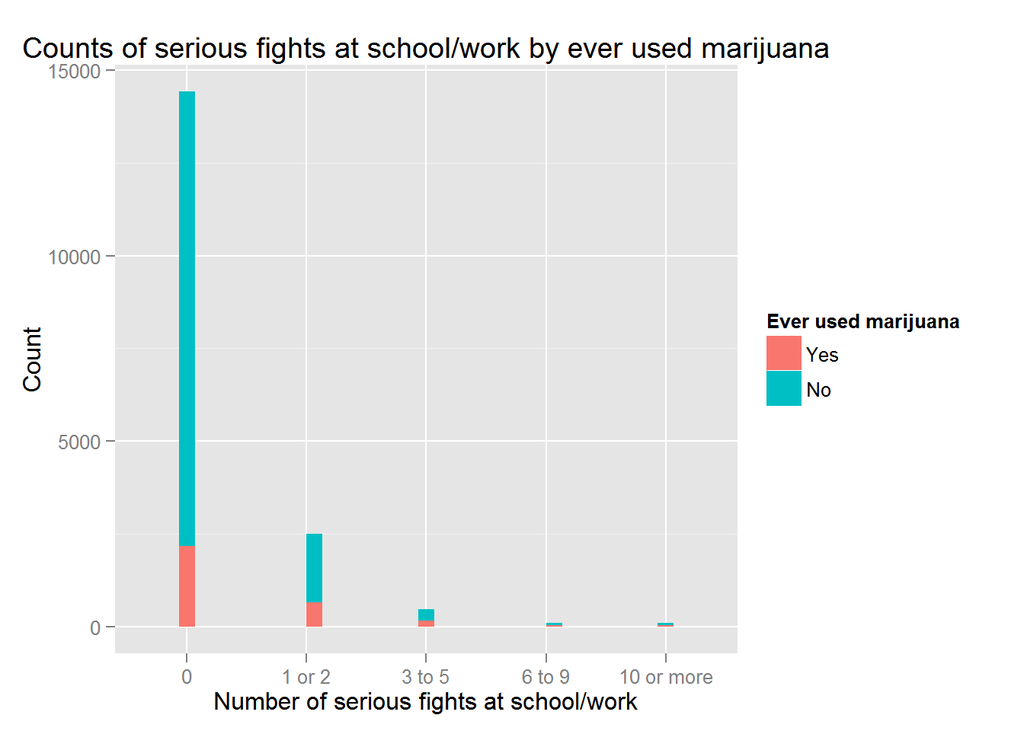

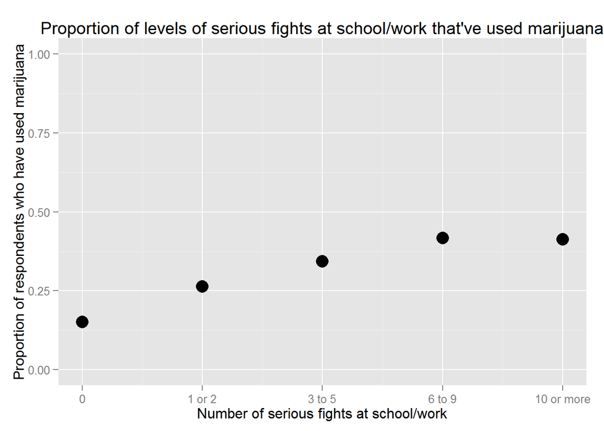

This is very similar to the results of the same analysis with cigarette use, except that the proportion of marijuana users who have been in 10+ fights is a bit higher than the proportion of cigarette users in the same bin. There is a difference in proportions of .26 between those who have never been in fights and those who have been in 10+.

#### Age

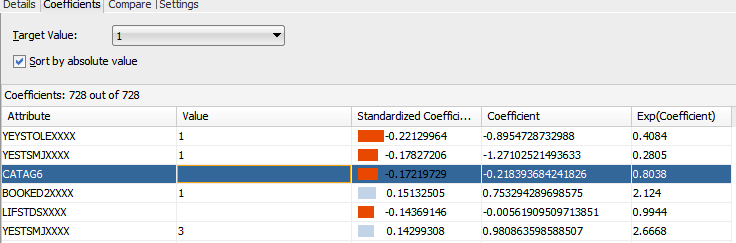

Age in 6 intervals, CATAG6, was also one of the highest confidence predictors for marijuana use and alcohol use by age is also included as reference.

```
## stat_bin: binwidth defaulted to range/30. Use 'binwidth = x' to adjust this.
```

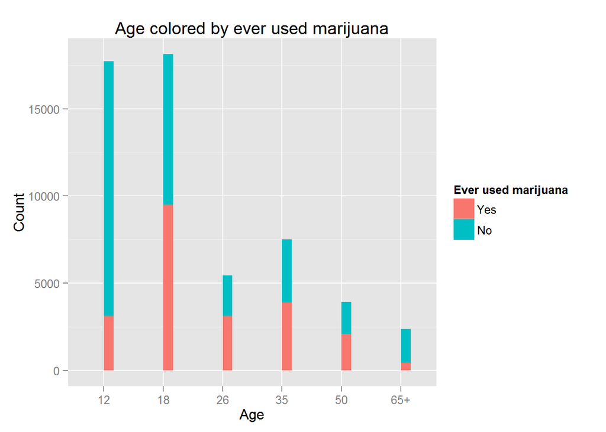

```
## stat_bin: binwidth defaulted to range/30. Use 'binwidth = x' to adjust this.
```

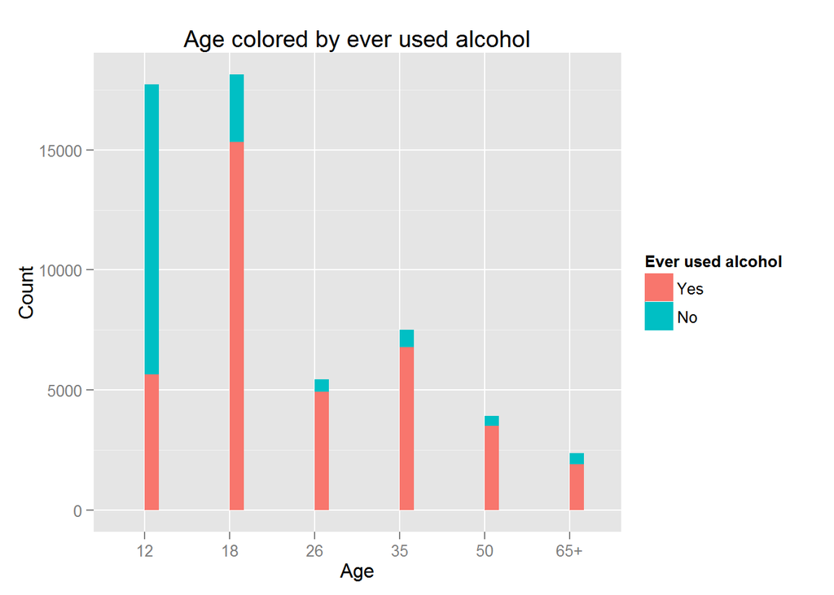

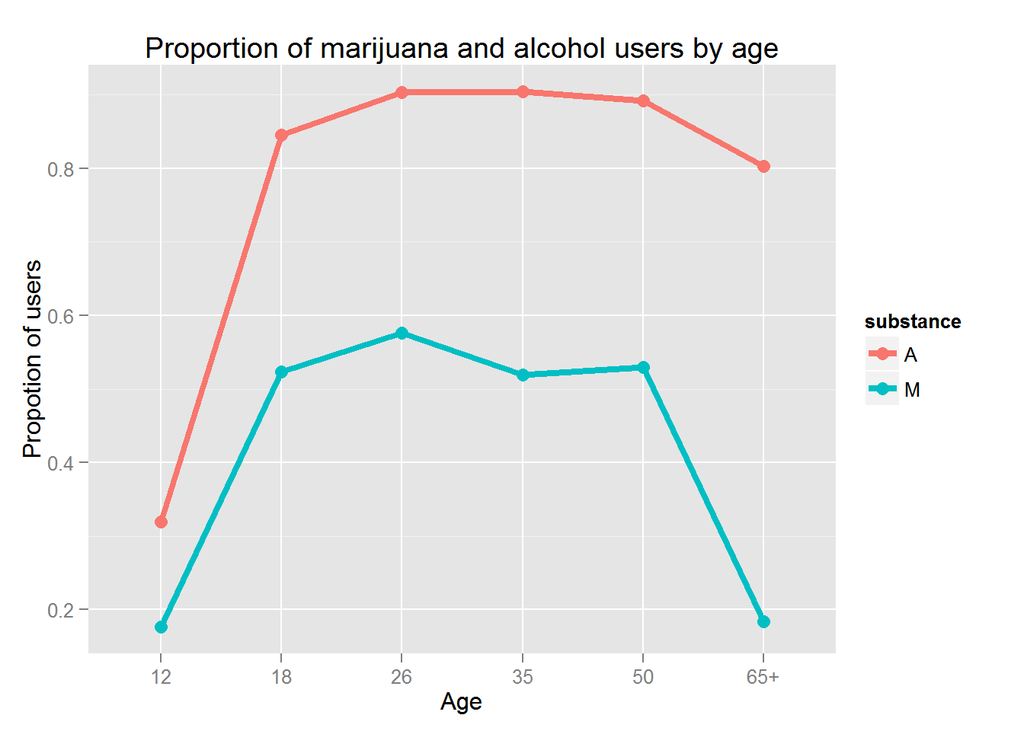

Especially when looking at the first and last age categories (12-17 and 51-65+) we can see that the gap between alcohol and marijuana use due to legality is shrinking as time goes on. For the 12-17 age group there is a difference of .1 between the proportions while the 51-65+ age group has a difference of .6. This may be explained by marijuana legalization and the increase of its use for its medicinal properties. It should also be noted that both drugs rise at the same rate and stay relatively level for most ages but once the 60’s are considered marijuana drops to the level of use of 12 year olds while alcohol remains steady or drops a tiny bit. So regardless of marijuana’s reported benefits as a medicine, the 60+ population uses much less marijuana than alcohol.